# Chapter 9: Clustering (A Data Mining Tool)

Cluster analysis is used when the data consist of unlabelled observations, meaning the true group memberships are unknown. It is an unsupervised learning technique that seeks to discover natural groupings or patterns in the data without prior knowledge of class labels.

Cluster analysis (or clustering) groups observations so that those within the same cluster are more similar to each other than to those in different clusters. This process is central to exploratory data analysis and is widely applied to reveal hidden structures or relationships that may not be immediately evident. In essence, clustering attempts to uncover underlying populations or sub-populations when their number and characteristics are not known beforehand.

The need for clustering arises when a dataset may contain multiple distinct groups, even though no group labels exist. Historically, clustering methods received limited attention, but their importance has surged, particularly in modern fields such as bioinformatics, genomics, marketing analytics, image segmentation, and social network analysis. Today, clustering is a fundamental tool in data science and machine learning for identifying latent structure in data.

The goal of cluster analysis is to determine whether undefined groups exist within the dataset and to characterize those groups. The resulting clusters can reveal meaningful insights and guide further statistical or predictive modeling.

For example, a marketing department might apply clustering to segment customers based on purchasing behavior or survey responses, enabling targeted advertising strategies, such as identifying customers likely to buy a product, those unlikely to purchase, and groups with specific preferences or needs.

Customer Segmentation (Marketing Analytics)

Cluster analysis is widely used in marketing and business analytics to identify distinct groups of customers with similar purchasing behaviors, interests, or demographic traits. By examining transaction histories, spending levels, product preferences, and engagement patterns, organizations can segment shoppers into meaningful categories such as budget-conscious buyers, brand-loyal customers, and premium or high-value consumers. In online commerce settings, clustering also plays a critical role in analyzing click-stream data—capturing browsing patterns, time spent on product pages, cart-abandonment behavior, and likelihood of purchase. These clustering insights help firms develop targeted marketing strategies, personalized recommendations, loyalty programs, and pricing models tailored to each segment.

Beyond spending behavior, demographic features such as age, income, education level, lifestyle choices, and geographic location can be used to cluster consumers into meaningful market groups. Understanding these audience profiles enables companies to optimize customer engagement and craft differentiated advertising campaigns. For example, younger tech-savvy users may respond to digital-first promotional strategies, whereas older consumers may respond to traditional or personalized outreach. Overall, clustering empowers businesses to move beyond a “one-size-fits-all” marketing approach, offering insights that increase customer satisfaction, improve retention, and ultimately enhance business profitability.

Gene Expression & Biological Data (Bioinformatics)

In the biological and biomedical sciences, clustering techniques play a crucial role in analyzing high-dimensional genetic and genomic data. One key application is grouping gene expression profiles to uncover previously unknown disease subtypes, as seen in cancer genomics where clustering can reveal molecular signatures associated with different tumor types or treatment responses. Similarly, in single-cell RNA sequencing studies, clustering allows researchers to identify subpopulations of cells that differ in function, developmental stage, or cellular state—providing insights into tissue heterogeneity, stem cell differentiation processes, and immune system dynamics. These biologically meaningful clusters often form the foundation for downstream analyses, including biomarker discovery and pathway enrichment studies.

Beyond molecular expression data, clustering is also applied in evolutionary biology and taxonomy to group species based on morphological features, genetic similarities, or phylogenetic relationships. This helps scientists classify organisms, understand evolutionary lineage patterns, and detect subtle distinctions between closely related species. In all these contexts, clustering serves as an essential exploratory tool for uncovering latent biological structure hidden within complex datasets, enabling researchers to generate hypotheses, guide experimental designs, and advance biological discovery in the absence of predefined labels.

#### Two Clustering Approaches

1. Partitioning Methods

k-means clustering:

Divides data into k clusters by minimizing within-cluster variation.

Requires specifying the number of clusters in advance.

Works well for large datasets and numerical variables.

2. Hierarchical Clustering

This method builds a hierarchy of clusters where groups can be nested within larger groups. Unlike k-means, it does not require the number of clusters to be specified initially.

Types of hierarchical clustering:

Agglomerative (bottom-up): Starts with each observation as its own cluster and repeatedly merges the most similar clusters until all observations form a single cluster.

Divisive (top-down): Begins with all observations in one cluster and recursively splits them into smaller clusters.

Hierarchical clustering is often visualized using a dendrogram, which helps determine the appropriate number of clusters.

## **k-Means Clustering**

The **k-means clustering** method partitions $n$ observations into $K$ clusters by minimizing the sum of squared distances between data points and their corresponding cluster centroids.

The optimization problem is:

$$ \underset{C, \{\mu_k\}_{k=1}^K}{\min} \sum_{k=1}^K \sum_{C(i)=k} \| x_i - \mu_k \|^2 $$

where

- $C: \{1, \ldots, n\} \to \{1, \ldots, K\}$ assigns each observation to a cluster, and
- $\mu_k$ is the mean (centroid) of cluster $k$.

This objective seeks to minimize the total **within-cluster sum of squares** by iteratively updating assignments and centroids.

### **Steps**

1. **Choose number of clusters $K$**  
   Select how many clusters to divide the data into.
2. **Initialize centroids**  
   Randomly choose $K$ points from the data as initial centroids  
   *(or use the more stable `k-means++` initialization)*.
3. **Assign points to nearest centroid**  
   For each point, compute its distance to each centroid and assign it to the closest one.
4. **Update centroids**  
   Recompute each centroid as the mean of points belonging to that cluster:

   $$ \mu_k = \frac{1}{|C_k|} \sum_{i \in C_k} x_i $$
5. **Repeat until convergence**  
   Alternate between assigning points and re-computing centroids until assignments do not change (or a max iteration count is reached).

The clustering quality is measured by the **Within-Cluster Sum of Squares (WCSS)**:

$$ \text{WCSS} = \sum_{k=1}^{K} \sum_{i \in C_k} \| x_i - \mu_k \|^2 $$

Lower WCSS indicates more compact clusters.

### **Practical Notes**

- Run k-means multiple times to avoid poor results from random initialization
- Works best for spherical, similarly sized clusters
- Sensitive to outliers and scaling — recommend standardizing variables
- Efficient and widely used for large datasets

The visulziation of the kmeans method:

https://shabal.in/visuals/kmeans/1.html

#### Clustering Example: Wine Chemical Profiles (UCI Wine Data)

**Objective.**  
Use clustering to discover natural groupings of wines based on their chemical measurements. Although the dataset includes a known cultivar label (column `V1`), we **do not use labels** when fitting the clustering models. After clustering, we may compare discovered clusters to the labels **only for evaluation**, not for training.

**Data.**  
The dataset contains 178 wines with 13 continuous variables. Your code below loads the data and removes the label column so the clustering uses **unlabeled** features:

```r
#R function for k mean method

loc = "http://archive.ics.uci.edu/ml/machine-learning-databases/wine/wine.data"
dat0 = read.csv(loc, header= FALSE)
#str(dat0)

#Label information: V1 (class)

#Data from clustering analysis
#V1 is the label information, for clusering, no group information is needed.
dat = dat0[,-1]

#data standazation
dat.s = scale(dat)
str(dat)
```

```
'data.frame':	178 obs. of  13 variables:
 $ V2 : num  14.2 13.2 13.2 14.4 13.2 ...
 $ V3 : num  1.71 1.78 2.36 1.95 2.59 1.76 1.87 2.15 1.64 1.35 ...
 $ V4 : num  2.43 2.14 2.67 2.5 2.87 2.45 2.45 2.61 2.17 2.27 ...
 $ V5 : num  15.6 11.2 18.6 16.8 21 15.2 14.6 17.6 14 16 ...
 $ V6 : int  127 100 101 113 118 112 96 121 97 98 ...
 $ V7 : num  2.8 2.65 2.8 3.85 2.8 3.27 2.5 2.6 2.8 2.98 ...
 $ V8 : num  3.06 2.76 3.24 3.49 2.69 3.39 2.52 2.51 2.98 3.15 ...
 $ V9 : num  0.28 0.26 0.3 0.24 0.39 0.34 0.3 0.31 0.29 0.22 ...
 $ V10: num  2.29 1.28 2.81 2.18 1.82 1.97 1.98 1.25 1.98 1.85 ...
 $ V11: num  5.64 4.38 5.68 7.8 4.32 6.75 5.25 5.05 5.2 7.22 ...
 $ V12: num  1.04 1.05 1.03 0.86 1.04 1.05 1.02 1.06 1.08 1.01 ...
 $ V13: num  3.92 3.4 3.17 3.45 2.93 2.85 3.58 3.58 2.85 3.55 ...
 $ V14: int  1065 1050 1185 1480 735 1450 1290 1295 1045 1045 ...
```

```r
# The number of classes shall be given: k
#Suppose that we will use 6 clusters
#For K-means we need to specify the number of clusters,
#The initial clusters depend on randomization
set.seed(3)

fit.6 = kmeans(x=dat.s, centers=6)
fit.6

#Cluster means:  the center of these 6 groups
#The center for group 1 is (-0.66900742 -0.5047221  0.7417080  0.7725728  2.4949041  0.2794397  0.4374796, -0.4066097  1.0794821 -0.6397355  0.6564708  0.47474528  0.02772796)

#Clustering vector:  6 6 6 6 1 , ....
#The first observation is in group 6,  the fifth observation is in group 1, ...
```

```
K-means clustering with 6 clusters of sizes 8, 26, 25, 40, 25, 54

Cluster means:
           V2         V3         V4         V5         V6         V7         V8
1 -0.66900742 -0.5047221  0.7417080  0.7725728  2.4949041  0.2794397  0.4374796
2  0.31666165  0.5857971  0.3085068  0.6464624  0.2766140 -0.9533432 -1.0805029
3 -0.72505388  0.1930380 -0.2103813  0.1308722 -0.5084251  0.7268305  0.6302497
4 -0.92953105 -0.6611475 -0.6461481  0.1692006 -0.6645604 -0.4947061 -0.2785876
5 -0.02342616  1.2689940  0.1118419  0.4566633 -0.4972226 -0.9956241 -1.3347931
6  0.98170555 -0.3944046  0.2658253 -0.8230559  0.4550446  0.9085091  0.9879690
          V9        V10        V11        V12         V13         V14
1 -0.4066097  1.0794821 -0.6397355  0.6564708  0.47474528  0.02772796
2  0.2230672 -0.4665827  1.5989875 -1.3938885 -1.44443010 -0.37547350
3 -0.6030688  0.6602521 -0.7397232  0.1354086  0.65791677 -0.68697404
4  0.3868604 -0.4243821 -0.9178505  0.6265021  0.05924672 -0.77139566
5  1.2096587 -1.0498638  0.1980386 -0.9530907 -1.07168401 -0.42111817
6 -0.6145561  0.5594606  0.2555620  0.4883575  0.77280616  1.26108553

Clustering vector:
  [1] 6 6 6 6 1 6 6 6 6 6 6 6 6 6 6 6 6 6 6 6 6 3 6 6 6 1 6 6 6 6 6 6 6 6 6 6 6
 [38] 6 6 6 6 3 6 3 6 6 6 6 6 6 6 6 6 6 6 6 6 6 6 4 4 4 4 3 4 3 3 4 4 1 4 3 4 1
 [75] 3 4 4 4 1 3 4 3 4 5 3 4 4 4 4 4 4 4 4 3 3 1 1 4 3 3 4 4 3 4 4 4 4 4 4 3 3
[112] 3 4 4 4 4 4 4 5 4 3 1 3 3 3 3 3 4 4 5 2 2 2 2 5 5 5 5 5 5 5 5 5 5 2 5 5 5
[149] 2 2 2 2 2 2 2 5 2 5 2 2 5 5 5 5 2 5 2 2 2 2 5 2 2 5 2 2 2 2

Within cluster sum of squares by cluster:
[1] 104.5911 150.2175 171.2228 257.8065 112.9720 243.2208
 (between_SS / total_SS =  54.8 %)

Available components:

[1] "cluster"      "centers"      "totss"        "withinss"     "tot.withinss"
[6] "betweenss"    "size"         "iter"         "ifault"
```

```r
#The number of clusters = 7
# K-means method
# The number of classes shall be given: k
#Suppose that we will use 7 clusters
#For K-means we need to specify the number of clusters,
set.seed(613)

fit.7 = kmeans(x=dat, centers=7)
fit.7

#If the numuber of classes k = 3

fit.3 = kmeans(x=dat, centers=3)
fit.3

#For 3 classes clustering
#The center of the one cluster is (12.92984 2.504032 2.408065 19.89032 103.59677 2.111129 1.584032 0.3883871,1.503387 5.650323 0.8839677 2.365484  728.3387 )
```

```
K-means clustering with 7 clusters of sizes 30, 34, 28, 23, 20, 17, 26

Cluster means:
        V2       V3       V4       V5        V6       V7       V8        V9
1 12.99733 2.662000 2.364000 19.33000 102.43333 2.109667 1.574333 0.4026667
2 12.53176 2.288529 2.317941 20.71471  93.61765 1.912941 1.622941 0.4026471
3 12.70893 2.771071 2.398214 21.36071  96.42857 1.899643 1.203214 0.4082143
4 12.39130 2.379565 2.223913 20.52174  88.91304 2.390870 2.238696 0.3547826
5 13.92050 1.769000 2.497500 17.20000 106.65000 2.908000 3.081500 0.2955000
6 13.09824 2.297647 2.440000 19.52941 112.47059 2.380000 2.055882 0.3470588
7 13.69923 1.978462 2.376154 16.91538 104.15385 2.823077 2.963077 0.2784615
       V10      V11       V12      V13       V14
1 1.539000 5.824667 0.8986667 2.346000  710.2333
2 1.350882 4.669706 0.9129412 2.332647  483.6471
3 1.291071 5.238214 0.8375000 2.149286  599.7143
4 1.642174 2.891304 1.0308696 2.857391  364.5217
5 1.908500 6.322500 1.1170000 3.008500 1360.8500
6 1.729412 5.412941 0.9132941 2.720000  871.6471
7 1.907308 5.199615 1.0538462 3.187692 1076.3462

Clustering vector:
  [1] 7 7 7 5 1 5 5 5 7 7 5 5 5 7 5 5 5 7 5 6 1 1 7 7 6 6 7 5 6 7 5 5 7 5 7 6 6
 [38] 7 7 1 6 7 7 1 6 7 7 7 7 5 7 5 7 5 7 7 6 5 5 2 1 2 3 4 4 1 2 2 1 1 6 4 2 7
 [75] 6 2 4 2 1 2 4 1 3 2 2 2 2 3 1 3 2 2 2 4 4 6 3 2 1 4 1 3 2 4 1 4 2 2 4 1 3
[112] 4 3 2 4 4 2 4 4 3 3 2 4 4 4 4 4 2 4 3 3 2 3 3 3 1 1 2 3 3 3 1 2 3 6 6 4 3
[149] 3 3 2 2 2 1 3 1 2 6 1 3 2 1 3 1 3 2 1 1 1 3 2 2 1 1 1 6 6 3

Within cluster sum of squares by cluster:
[1]  50108.70  38470.99  34420.87  38417.21 294545.54  36200.83  99361.13
 (between_SS / total_SS =  96.6 %)

Available components:

[1] "cluster"      "centers"      "totss"        "withinss"     "tot.withinss"
[6] "betweenss"    "size"         "iter"         "ifault"
```

```
K-means clustering with 3 clusters of sizes 62, 69, 47

Cluster means:
        V2       V3       V4       V5        V6       V7       V8        V9
1 12.92984 2.504032 2.408065 19.89032 103.59677 2.111129 1.584032 0.3883871
2 12.51667 2.494203 2.288551 20.82319  92.34783 2.070725 1.758406 0.3901449
3 13.80447 1.883404 2.426170 17.02340 105.51064 2.867234 3.014255 0.2853191
       V10      V11       V12      V13       V14
1 1.503387 5.650323 0.8839677 2.365484  728.3387
2 1.451884 4.086957 0.9411594 2.490725  458.2319
3 1.910426 5.702553 1.0782979 3.114043 1195.1489

Clustering vector:
  [1] 3 3 3 3 1 3 3 3 3 3 3 3 3 3 3 3 3 3 3 1 1 1 3 3 1 1 3 3 1 3 3 3 3 3 3 1 1
 [38] 3 3 1 1 3 3 1 1 3 3 3 3 3 3 3 3 3 3 3 3 3 3 2 1 2 1 2 2 1 2 2 1 1 1 2 2 3
 [75] 1 2 2 2 1 2 2 1 1 2 2 2 2 2 1 1 2 2 2 2 2 1 1 2 1 2 1 2 2 2 1 2 2 2 2 1 2
[112] 2 1 2 2 2 2 2 2 2 1 2 2 2 2 2 2 2 2 2 1 2 2 1 1 1 1 2 2 2 1 1 2 2 1 1 2 1
[149] 1 2 2 2 2 1 1 1 2 1 1 1 2 1 2 1 1 2 1 1 1 1 2 2 1 1 1 1 1 2

Within cluster sum of squares by cluster:
[1]  566572.5  443166.7 1360950.5
 (between_SS / total_SS =  86.5 %)

Available components:

[1] "cluster"      "centers"      "totss"        "withinss"     "tot.withinss"
[6] "betweenss"    "size"         "iter"         "ifault"
```

```r
str(fit.7)
```

```
List of 9
 $ cluster     : int [1:178] 7 7 7 5 1 5 5 5 7 7 ...
 $ centers     : num [1:7, 1:13] 13 12.5 12.7 12.4 13.9 ...
  ..- attr(*, "dimnames")=List of 2
  .. ..$ : chr [1:7] "1" "2" "3" "4" ...
  .. ..$ : chr [1:13] "V2" "V3" "V4" "V5" ...
 $ totss       : num 17592296
 $ withinss    : num [1:7] 50109 38471 34421 38417 294546 ...
 $ tot.withinss: num 591525
 $ betweenss   : num 1.7e+07
 $ size        : int [1:7] 30 34 28 23 20 17 26
 $ iter        : int 3
 $ ifault      : int 0
 - attr(*, "class")= chr "kmeans"
```

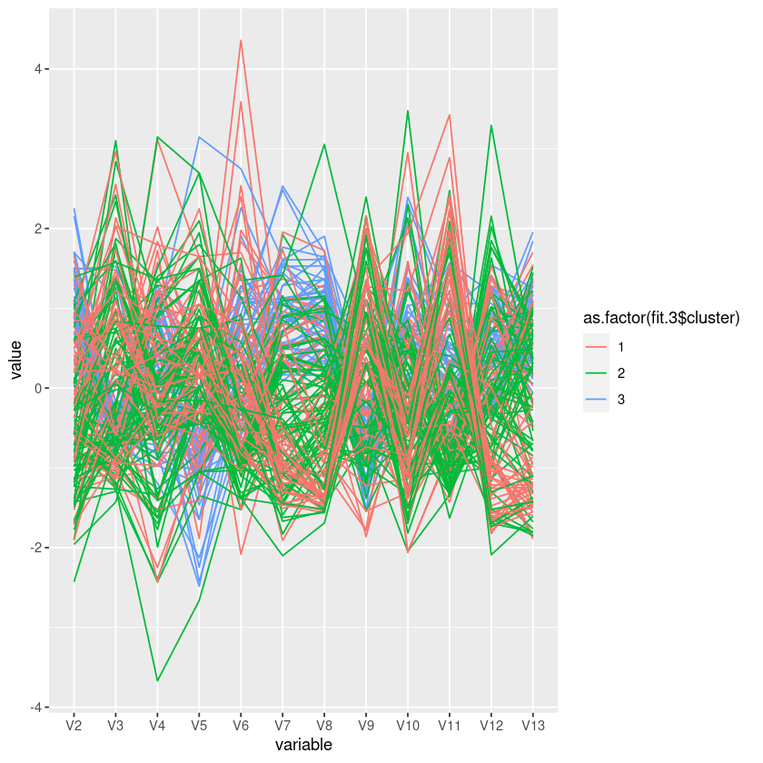

```
effect of variables:
 modified item       Var
 "height of face   " "V2"
 "width of face    " "V3"
 "structure of face" "V4"
 "height of mouth  " "V5"
 "width of mouth   " "V6"
 "smiling          " "V7"
 "height of eyes   " "V8"
 "width of eyes    " "V9"
 "height of hair   " "V10"
 "width of hair   "  "V11"
 "style of hair   "  "V12"
 "height of nose  "  "V13"
 "width of nose   "  "V14"
 "width of ear    "  "V2"
 "height of ear   "  "V3"
```

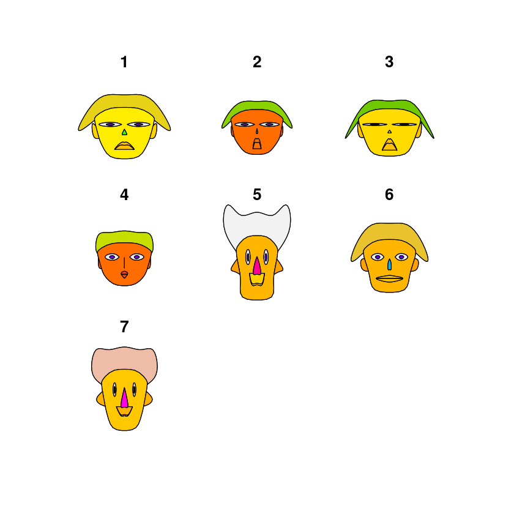

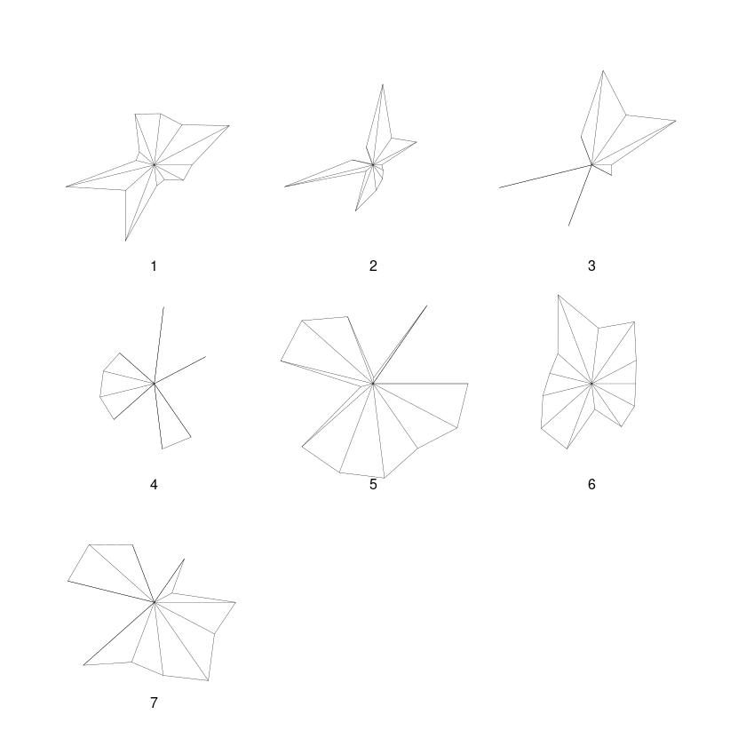

```r
#Visulization of the centers of each cluster
library(GGally)
dat.with.cluster= cbind(as.factor(fit.3$cluster), dat)
ggparcoord(dat.with.cluster, columns = c(2:13), groupColumn=1)

library(aplpack)
faces(fit.7$centers)
stars(fit.7$centers)
```

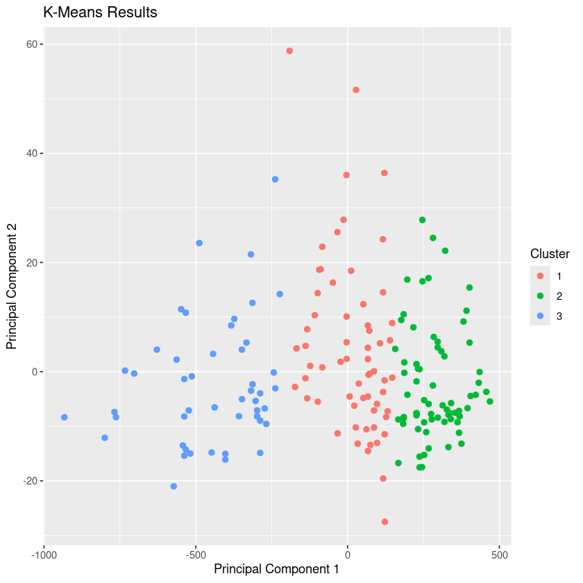

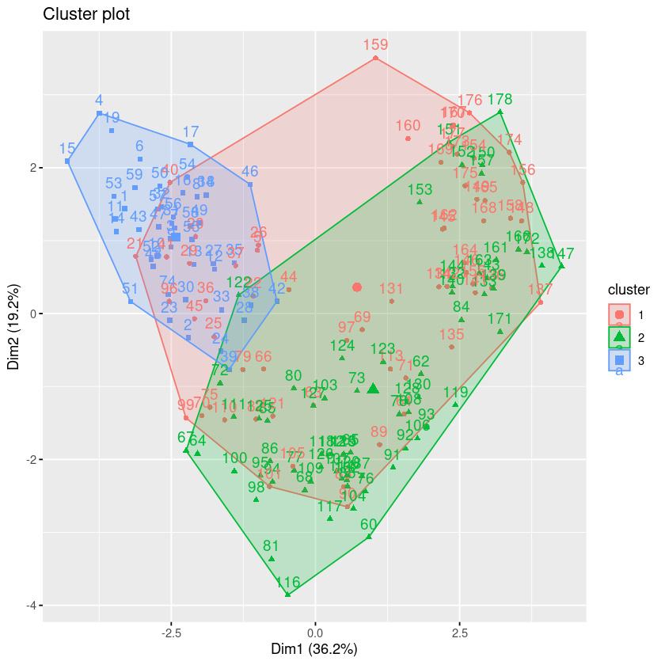

```r
#Plot the result of clustering
library(useful)
plot(fit.3, data=dat)

#clustering/factor algorithms & visualization
library(factoextra)
fviz_cluster(fit.3, data = dat)
```

### **Interpretation of K-Means Clustering Results (Wine Dataset)**

The scatter plot displays the results of applying **k-means clustering with (K = 3)** to the Wine dataset, projected onto the first two principal components (PC1 and PC2). Each point represents a wine sample, and the color denotes the assigned cluster group discovered by the k-means algorithm.

[figure not shown]

```r
#Plot the result of clustering
plot(fit.6, data=dat.s)
```

### **Selecting $K$: Determining the Number of Clusters in k-Means**

A key challenge in k-means clustering is choosing the appropriate number of clusters, denoted by $K$. If $K$ is too small, very different observations may be forced into the same cluster; if $K$ is too large, the model may overfit by creating clusters that are not meaningful. To evaluate a candidate value of $K$, we compute the **within-cluster sum of squares (WCSS)** — the total squared distance between each observation and the centroid of the cluster it belongs to. Lower WCSS indicates more compact clusters. However, because WCSS will always decrease as $K$ increases, we need a principled way to balance **model fit** with **model simplicity**.

A practical strategy is to run k-means with different values of $K$ (e.g., $K = 1, 2, 3, \dots$) and examine how the WCSS changes. These results are visualized with a **scree plot** (also called an **elbow plot**), where the x-axis represents $K$ and the y-axis represents WCSS:

$$ \text{WCSS}(K) = \sum_{k=1}^{K} \sum_{i \in C_k} \lVert x_i - \mu_k \rVert^2 $$

Initially, increasing $K$ sharply reduces WCSS, because adding clusters allows better separation. However, after a certain point, the improvement becomes marginal. The point where the decrease in WCSS begins to level off forms the characteristic **“elbow”** in the plot. This **elbow criterion** suggests selecting the value of $K$ near this bend, which is the smallest number of clusters that still achieves a substantial reduction in WCSS. In other words, we choose $K$ such that adding one more cluster does **not** significantly improve the ability to explain the data variability. This method helps ensure that the selected model yields interpretable, meaningful clusters while avoiding unnecessary complexity.

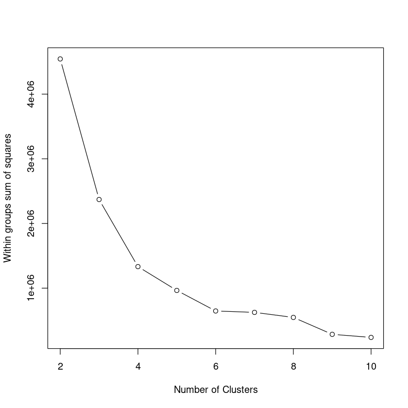

```r
#the function kmeans involves randomization, so set a seed to have reproducible results.
set.seed(142)

#The selection of number of clusters for k-means method

#With cluster SS
wss = (nrow(dat)-1)*sum(apply(dat,2,var))

#The max number of k is 10
for (k in 2:10) wss[k] = sum(kmeans(dat, centers=k)$withinss)
plot(2:10, wss[2:10], type="b", xlab="Number of Clusters",   ylab="Within groups sum of squares")

#The optimal one is 6
```

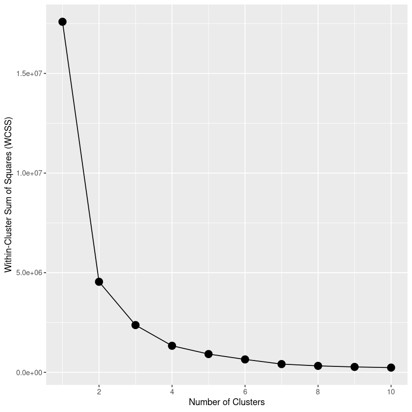

```r
library(tidyverse)
# Decide how many clusters to consider
n_clusters <- 10

# Initialize a vector to store within-cluster sum of squares (wss) for each model
wss <- numeric(n_clusters)

# Set a random seed for reproducibility
set.seed(142)

# Test models with 1 to n_clusters
for (i in 1:n_clusters) {
  # Fit the k-means model with 'i' clusters
  km.out <- kmeans(dat, centers = i, nstart = 20)

  # Save the total within-cluster sum of squares for the current model
  wss[i] <- km.out$tot.withinss
}


# Prepare data for plotting
wss_df <- tibble(clusters = 1:n_clusters, wss = wss)

# Create the scree plot
scree_plot <- ggplot(wss_df, aes(x = clusters, y = wss, group = 1)) +
  geom_point(size = 4) +
  geom_line() +
  scale_x_continuous(breaks = c(2, 4, 6, 8, 10)) +
  xlab('Number of Clusters') +
  ylab('Within-Cluster Sum of Squares (WCSS)')

# Display the plot
scree_plot
#This plot will help you visually determine the optimal number of clusters by observing where the WCSS begins to level off.
```

# Application:

Using cluster analysis to perform image segmentation: to group similar pixels in the image together, we can apply clustering to create clusters having similar pixels in the same group.

```r
library(jpeg)
img = readJPEG("~/data/Horse.jpg")
dim(img)
```

1. 343

2. 494

3. 3

1. 169442

2. 3

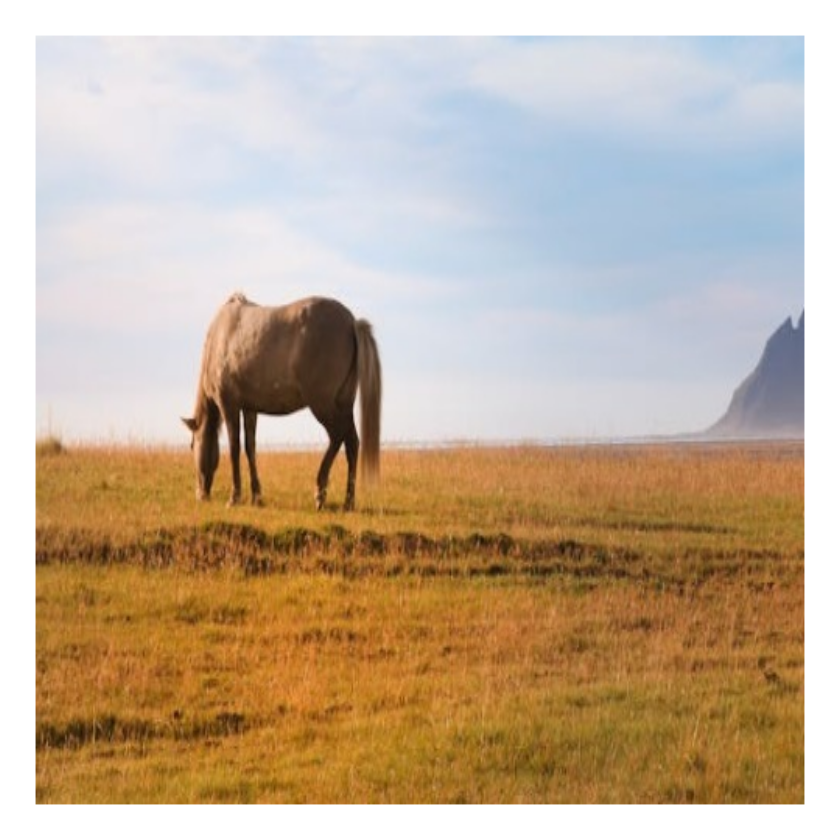

```r
# generate a blank image
 par(mar=rep(0.2, 4))
 plot(c(0, 343), c(0, 494), xaxt = 'n', yaxt = 'n', bty = 'n', pch = '', ylab = '', xlab = '')
#plot the image on the empty image
 rasterImage(img, 0, 0, 343, 494)

# vecterization to each layer (r/g/b) of the image.
     img_expand = apply(img, 3, c)
     dim(img_expand)
```

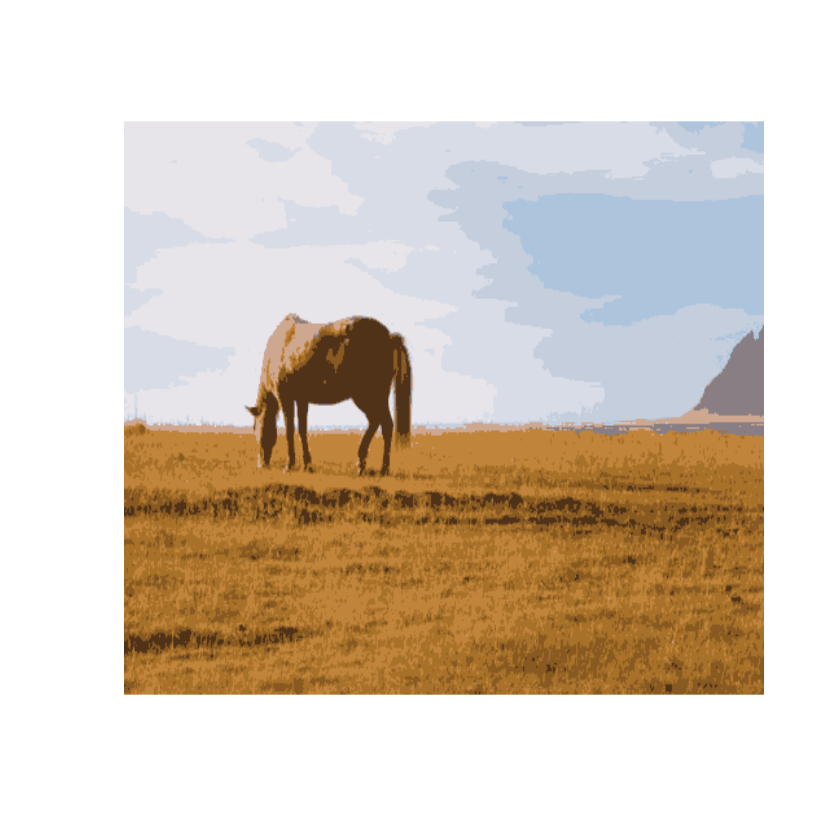

```r
#The next step is to perform the k-mean and obtain the cluster. For example, let’s try 15 clusters.
  kmeanfit.10 = kmeans(img_expand, 10)

# to produce a new graph, we simply use the cluster mean to replace all the values in the
#image for all observations in the same cluster
  new_img_expand = kmeanfit.10$centers[kmeanfit.10$cluster, ]

# now we need to convert this back to the array that can be plotted as an image.
  # this is a lazy way to do it, but get the job done
  new_img = img
  new_img[, ,1] = matrix(new_img_expand[,1], 343, 494)
  new_img[, ,2] = matrix(new_img_expand[,2], 343, 494)
  new_img[, ,3] = matrix(new_img_expand[,3], 343, 494)

  # plot the new image
  plot(c(0, 343), c(0, 494), xaxt = 'n', yaxt = 'n', bty = 'n',
       pch = '', ylab = '', xlab = '')

  rasterImage(new_img, 0, 0, 343, 494)

#The selection of number of clusters for k-means method
```

## **Hierarchical Clustering**

Hierarchical clustering is a widely used **unsupervised learning** method that builds a hierarchy of clusters. Instead of specifying the number of clusters in advance (as required in $k$-means), hierarchical clustering creates a **tree-like structure** (called a **dendrogram**) that shows how observations are grouped at different distance thresholds. This approach is useful for visualizing nested cluster structures and exploring possible groupings at various levels of granularity. Hierarchical clustering is especially valuable when interpretability and structure discovery are priorities, offering insight into **how clusters form and merge** at different similarity levels.

There are two main strategies:

- **Agglomerative (Bottom-Up)** — the most common approach  
  Start with each observation as its own cluster. Then, iteratively merge the two closest clusters until all observations belong to a single cluster.
- **Divisive (Top-Down)**  
  Start with one large cluster containing all observations. Then, iteratively split clusters into smaller sub-clusters until each observation stands alone.

Agglomerative methods are more frequently used in practice because they are computationally simpler and scale better for typical data sizes.

### **Distance and Linkage Criteria**

To decide which clusters to merge or split at each step, hierarchical clustering relies on a **distance metric** (e.g., Euclidean distance) and a **linkage function**, which defines the distance between clusters $A$ and $B$ based on the distances between their points.

Let $x \in A$ and $y \in B$ represent data points in clusters $A$ and $B$. Common linkage functions include:

[output not shown]

- The result of hierarchical clustering is typically visualized using a **dendrogram**, where cutting the tree at a chosen height gives the final clusters.
- Different linkage methods can lead to **different clustering results**.
- Unlike $k$-means, hierarchical clustering **does not require pre-specifying $K$**, but you choose $K$ by selecting a cut level on the dendrogram.
- Works well for **small to medium-size datasets** and when the cluster structure is hierarchical or nested.

```r
#R codes for Hierarchical clustering
#Based on the distance matrix

# Ward Hierarchical Clustering
# Ward's method
#R function for k mean method

loc = "http://archive.ics.uci.edu/ml/machine-learning-databases/wine/wine.data"
dat0 = read.csv(loc, header= FALSE)
#Label information: V1 (class)

#Data from clustering analysis
#V1 is the label information, for clusering, no group information is needed.
dat = dat0[,-1]

str(dat)
```

```
'data.frame':	178 obs. of  13 variables:
 $ V2 : num  14.2 13.2 13.2 14.4 13.2 ...
 $ V3 : num  1.71 1.78 2.36 1.95 2.59 1.76 1.87 2.15 1.64 1.35 ...
 $ V4 : num  2.43 2.14 2.67 2.5 2.87 2.45 2.45 2.61 2.17 2.27 ...
 $ V5 : num  15.6 11.2 18.6 16.8 21 15.2 14.6 17.6 14 16 ...
 $ V6 : int  127 100 101 113 118 112 96 121 97 98 ...
 $ V7 : num  2.8 2.65 2.8 3.85 2.8 3.27 2.5 2.6 2.8 2.98 ...
 $ V8 : num  3.06 2.76 3.24 3.49 2.69 3.39 2.52 2.51 2.98 3.15 ...
 $ V9 : num  0.28 0.26 0.3 0.24 0.39 0.34 0.3 0.31 0.29 0.22 ...
 $ V10: num  2.29 1.28 2.81 2.18 1.82 1.97 1.98 1.25 1.98 1.85 ...
 $ V11: num  5.64 4.38 5.68 7.8 4.32 6.75 5.25 5.05 5.2 7.22 ...
 $ V12: num  1.04 1.05 1.03 0.86 1.04 1.05 1.02 1.06 1.08 1.01 ...
 $ V13: num  3.92 3.4 3.17 3.45 2.93 2.85 3.58 3.58 2.85 3.55 ...
 $ V14: int  1065 1050 1185 1480 735 1450 1290 1295 1045 1045 ...
```

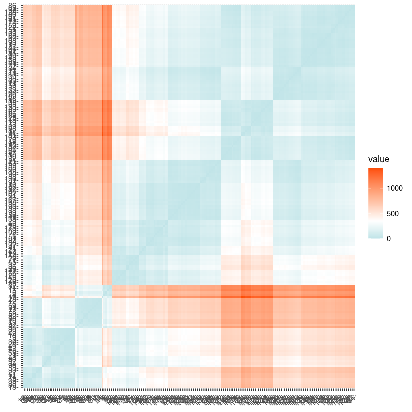

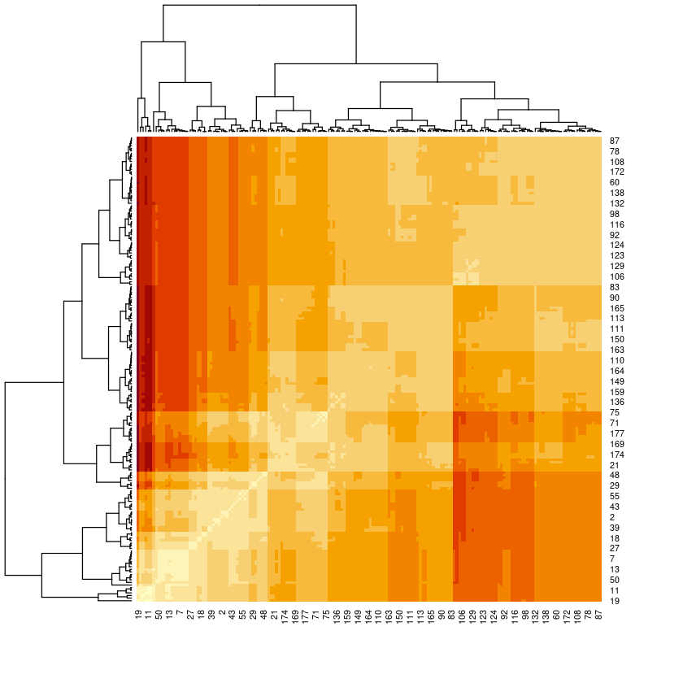

```r
#Calculate the distance matrix
dmat = dist(dat,method = "euclidean") # distance matrix

#Visulize the distance
library(factoextra)
fviz_dist(dmat, gradient = list(low = "#00AFBB", mid = "white", high = "#FC4E07"))

heatmap(as.matrix(dmat))
```

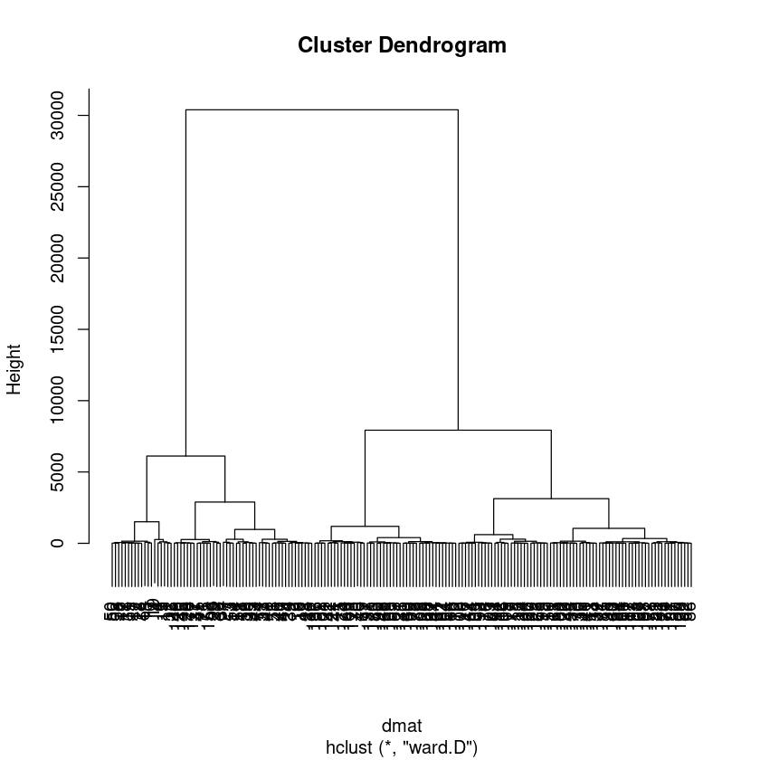

```r
#Partitioning Method with "ward" method
fit.ward = hclust(dmat, method="ward.D")
plot(fit.ward)
```

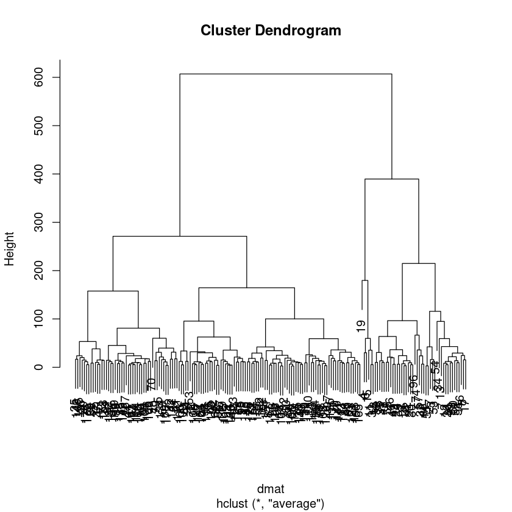

1. 1

2. 1

3. 1

4. 2

5. 3

6. 2

7. 1

8. 1

9. 1

10. 1

11. 2

12. 1

13. 1

14. 1

15. 2

16. 1

17. 1

18. 1

19. 2

20. 3

21. 3

22. 3

23. 1

24. 1

25. 3

26. 3

27. 1

28. 1

29. 3

30. 1

31. 1

32. 2

33. 1

34. 1

35. 1

36. 3

37. 3

38. 1

39. 1

40. 3

41. 3

42. 1

43. 1

44. 3

45. 3

46. 1

47. 1

48. 1

49. 1

50. 1

51. 1

52. 1

53. 1

54. 1

55. 1

56. 1

57. 1

58. 1

59. 1

60. 4

61. 3

62. 4

63. 4

64. 4

65. 4

66. 3

67. 4

68. 4

69. 3

70. 3

71. 3

72. 4

73. 4

74. 1

75. 3

76. 4

77. 4

78. 4

79. 3

80. 4

81. 4

82. 3

83. 4

84. 4

85. 4

86. 4

87. 4

88. 4

89. 3

90. 4

91. 4

92. 4

93. 4

94. 4

95. 4

96. 1

97. 4

98. 4

99. 3

100. 4

101. 3

102. 4

103. 4

104. 4

105. 3

106. 4

107. 4

108. 4

109. 4

110. 3

111. 4

112. 4

113. 4

114. 4

115. 4

116. 4

117. 4

118. 4

119. 4

120. 4

121. 4

122. 4

123. 4

124. 4

125. 4

126. 4

127. 4

128. 4

129. 4

130. 4

131. 4

132. 4

133. 4

134. 4

135. 3

136. 3

137. 3

138. 4

139. 4

140. 4

141. 4

142. 3

143. 4

144. 4

145. 3

146. 3

147. 4

148. 4

149. 3

150. 4

151. 4

152. 4

153. 4

154. 3

155. 4

156. 3

157. 4

158. 3

159. 3

160. 4

161. 4

162. 3

163. 4

164. 3

165. 4

166. 4

167. 3

168. 3

169. 3

170. 4

171. 4

172. 4

173. 3

174. 3

175. 3

176. 3

177. 3

178. 4

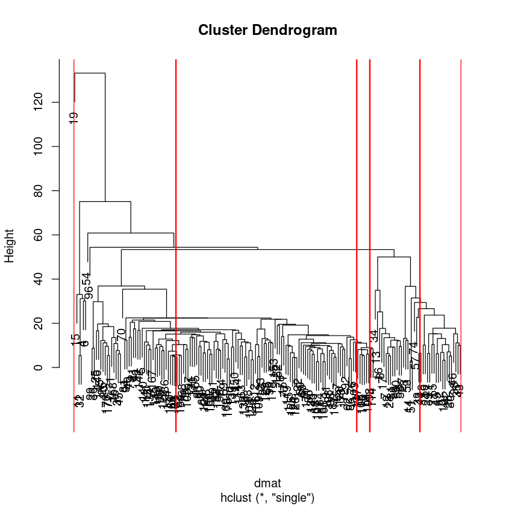

```r
#Hierarchical agglomerative clustering using “average” linkage
fit.average = hclust(dmat, method="average")

plot(fit.average)

#Hierarchical agglomerative clustering using “single” linkage
fit.single = hclust(dmat, method="single")

plot(fit.single)

groups = cutree(fit.average, k=4) # cut tree into 5 clusters
# draw dendogram with red borders around the 5 clusters
rect.hclust(fit.average, k=5, border="red")

groups
```

1. 1

2. 1

3. 1

4. 2

5. 3

6. 2

7. 1

8. 1

9. 1

10. 1

11. 2

12. 1

13. 1

14. 1

15. 2

16. 1

17. 1

18. 1

19. 2

20. 3

21. 3

22. 3

23. 1

24. 1

25. 3

26. 3

27. 1

28. 1

29. 3

30. 1

31. 1

32. 2

33. 1

34. 1

35. 1

36. 3

37. 3

38. 1

39. 1

40. 3

41. 3

42. 1

43. 1

44. 3

45. 3

46. 1

47. 1

48. 1

49. 1

50. 1

51. 1

52. 1

53. 1

54. 1

55. 1

56. 1

57. 1

58. 1

59. 1

60. 4

61. 3

62. 4

63. 4

64. 4

65. 4

66. 3

67. 4

68. 4

69. 3

70. 3

71. 3

72. 4

73. 4

74. 1

75. 3

76. 4

77. 4

78. 4

79. 3

80. 4

81. 4

82. 3

83. 4

84. 4

85. 4

86. 4

87. 4

88. 4

89. 3

90. 4

91. 4

92. 4

93. 4

94. 4

95. 4

96. 1

97. 4

98. 4

99. 3

100. 4

101. 3

102. 4

103. 4

104. 4

105. 3

106. 4

107. 4

108. 4

109. 4

110. 3

111. 4

112. 4

113. 4

114. 4

115. 4

116. 4

117. 4

118. 4

119. 4

120. 4

121. 4

122. 4

123. 4

124. 4

125. 4

126. 4

127. 4

128. 4

129. 4

130. 4

131. 4

132. 4

133. 4

134. 4

135. 3

136. 3

137. 3

138. 4

139. 4

140. 4

141. 4

142. 3

143. 4

144. 4

145. 3

146. 3

147. 4

148. 4

149. 3

150. 4

151. 4

152. 4

153. 4

154. 3

155. 4

156. 3

157. 4

158. 3

159. 3

160. 4

161. 4

162. 3

163. 4

164. 3

165. 4

166. 4

167. 3

168. 3

169. 3

170. 4

171. 4

172. 4

173. 3

174. 3

175. 3

176. 3

177. 3

178. 4

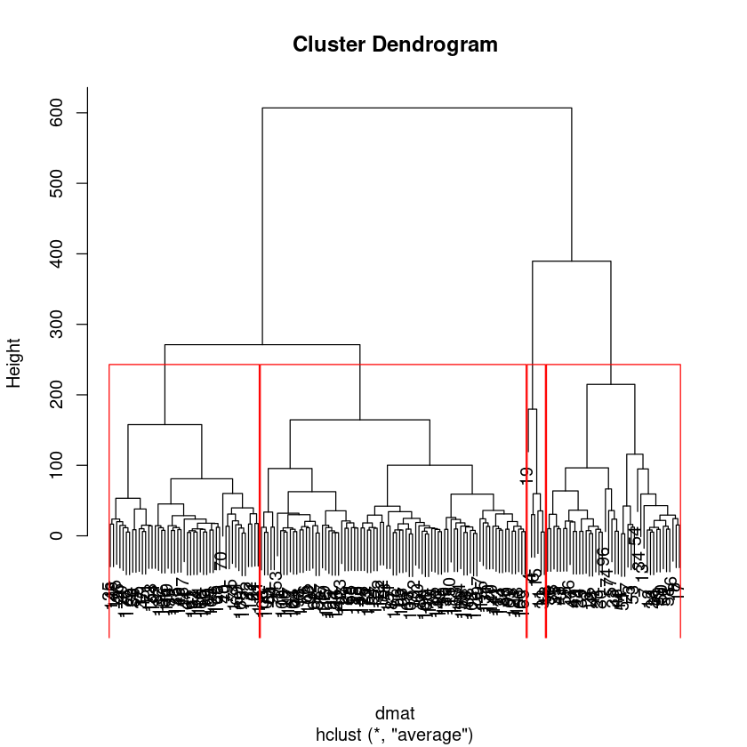

```r
plot(fit.average)
groups = cutree(fit.average, k=4) # cut tree into 5 clusters
groups
# draw dendogram with red borders around the 5 clusters
rect.hclust(fit.average, k=4, border="red")
```

```r
#str(dat)

library(tidyverse)

dat$groups = factor(groups)
str(dat)

dat.ave = dat%>% group_by(groups) %>% summarize(V2= mean(V2), V3= mean(V3), V4= mean(V4), V5= mean(V5), V6= mean(V6) )
```

```
'data.frame':	178 obs. of  14 variables:
 $ V2    : num  14.2 13.2 13.2 14.4 13.2 ...
 $ V3    : num  1.71 1.78 2.36 1.95 2.59 1.76 1.87 2.15 1.64 1.35 ...
 $ V4    : num  2.43 2.14 2.67 2.5 2.87 2.45 2.45 2.61 2.17 2.27 ...
 $ V5    : num  15.6 11.2 18.6 16.8 21 15.2 14.6 17.6 14 16 ...
 $ V6    : int  127 100 101 113 118 112 96 121 97 98 ...
 $ V7    : num  2.8 2.65 2.8 3.85 2.8 3.27 2.5 2.6 2.8 2.98 ...
 $ V8    : num  3.06 2.76 3.24 3.49 2.69 3.39 2.52 2.51 2.98 3.15 ...
 $ V9    : num  0.28 0.26 0.3 0.24 0.39 0.34 0.3 0.31 0.29 0.22 ...
 $ V10   : num  2.29 1.28 2.81 2.18 1.82 1.97 1.98 1.25 1.98 1.85 ...
 $ V11   : num  5.64 4.38 5.68 7.8 4.32 6.75 5.25 5.05 5.2 7.22 ...
 $ V12   : num  1.04 1.05 1.03 0.86 1.04 1.05 1.02 1.06 1.08 1.01 ...
 $ V13   : num  3.92 3.4 3.17 3.45 2.93 2.85 3.58 3.58 2.85 3.55 ...
 $ V14   : int  1065 1050 1185 1480 735 1450 1290 1295 1045 1045 ...
 $ groups: Factor w/ 4 levels "1","2","3","4": 1 1 1 2 3 2 1 1 1 1 ...
```

A tibble: 4 × 6

| groups <fct> | V2 <dbl> | V3 <dbl> | V4 <dbl> | V5 <dbl> | V6 <dbl> |
| --- | --- | --- | --- | --- | --- |
| 1 | 13.72524 | 1.882143 | 2.422857 | 17.17857 | 106.54762 |
| 2 | 14.13667 | 1.831667 | 2.411667 | 16.26667 | 107.66667 |
| 3 | 13.01553 | 2.557021 | 2.394255 | 19.48085 | 103.87234 |
| 4 | 12.54337 | 2.477711 | 2.319036 | 20.90843 | 93.38554 |

```
effect of variables:
 modified item       Var
 "height of face   " "V2"
 "width of face    " "V3"
 "structure of face" "V4"
 "height of mouth  " "V5"
 "width of mouth   " "V6"
 "smiling          " "V2"
 "height of eyes   " "V3"
 "width of eyes    " "V4"
 "height of hair   " "V5"
 "width of hair   "  "V6"
 "style of hair   "  "V2"
 "height of nose  "  "V3"
 "width of nose   "  "V4"
 "width of ear    "  "V5"
 "height of ear   "  "V6"
```

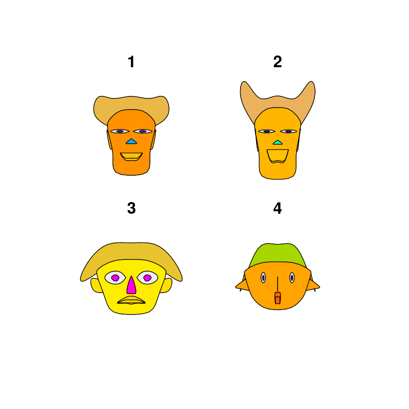

```r
dat.ave
library(aplpack)
faces(dat.ave[,2:6])
#make other plots
```

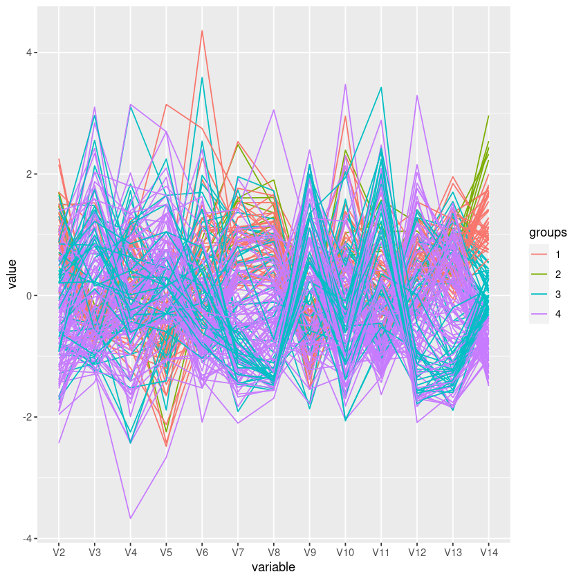

```r
#Plot the clustering results in a line plot
library(GGally)
ggparcoord(dat, columns = c(1:13), groupColumn=14)
```

### Example: **USArrests** (R Built-in Dataset)

**Data.** `USArrests` (R built-in) contains 50 U.S. states and 4 numeric variables (rates per 100,000, except `UrbanPop` is %):

- `Murder`, `Assault`, `UrbanPop`, `Rape`.

**Goal.** Use clustering to discover groups of U.S. states with similar violent-crime profiles. We will:

1. Standardize variables, 2) perform **hierarchical clustering** (dendrogram + cut at (K=4)), 3) run **k-means** with (K=4), and 4) compare/interpret clusters.

#### **Silhouette Analysis**

**Silhouette analysis** is a method used to evaluate the quality of a clustering solution by measuring how well each observation fits within its assigned cluster, compared to other clusters. It provides a numerical score, called the **silhouette value**, for every observation and summarizes the overall clustering structure.

- $s_i \approx 1$ — the observation is well matched to its own cluster and poorly matched to neighboring clusters
- $s_i \approx 0$ — the observation lies on the boundary between clusters
- $s_i < 0$ — the observation may be assigned to the wrong cluster

The **average silhouette score** across all observations gives a measure of clustering quality:

- **Closer to 1:** strong, well-separated clusters
- **Around 0:** overlapping or ambiguous clusters
- **Negative:** many observations are likely misclassified

Silhouette analysis is especially useful for:

- Evaluating how well clusters are separated
- Comparing different clustering solutions (e.g., $K=2, 3, 4, \dots$ in k-means)
- Identifying outliers or poorly assigned points within clusters

It provides both **numerical scores** and a **visual tool** (the silhouette plot), making it a popular diagnostic in unsupervised learning.

```
hc_cut
 1  2  3  4
 8 11 21 10
```

```
  cluster Murder Assault UrbanPop  Rape
1       1   1.45    0.98    -0.83  0.35
2       2   0.75    1.12     0.94  1.22
3       3  -0.44   -0.44     0.36 -0.28
4       4  -1.06   -1.10    -1.12 -1.03
```

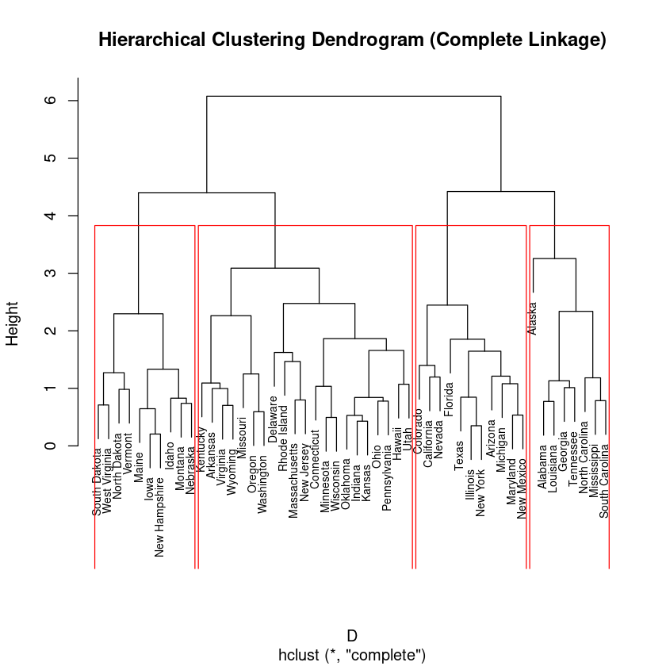

```r
dat = USArrests              # 50x4: Murder, Assault, UrbanPop, Rape
states = rownames(dat)

#Preprocessing: standardize (important for distance-based methods)
X = scale(dat)

#Hierarchical Clustering (Agglomerative, Complete Linkage)
D = dist(X, method = "euclidean")
hc = hclust(D, method = "complete")

# Dendrogram
plot(hc, labels = states, cex = 0.7, main = "Hierarchical Clustering Dendrogram (Complete Linkage)")
abline(h = 7, col = "gray40", lty = 2)  # visual cut line (tune as needed)

K = 4
hc_cut = cutree(hc, k = K)
table(hc_cut)

# draw dendogram with red borders around the 5 clusters
rect.hclust(hc, k=4, border="red")


# Cluster profiling (means by cluster, in standardized space)
hc_profile = aggregate(X, by = list(cluster = hc_cut), FUN = mean)
print(round(hc_profile, 2))
```

1. 13

2. 13

3. 16

4. 8

56.4031734582928

```
  cluster Murder Assault UrbanPop  Rape
1       1   0.70    1.04     0.72  1.28
2       2  -0.96   -1.11    -0.93 -0.97
3       3  -0.49   -0.38     0.58 -0.26
4       4   1.41    0.87    -0.81  0.02
    KMeans
Hier  1  2  3  4
   1  1  0  0  7
   2 11  0  0  0
   3  1  3 16  1
   4  0 10  0  0
```

[output not shown]

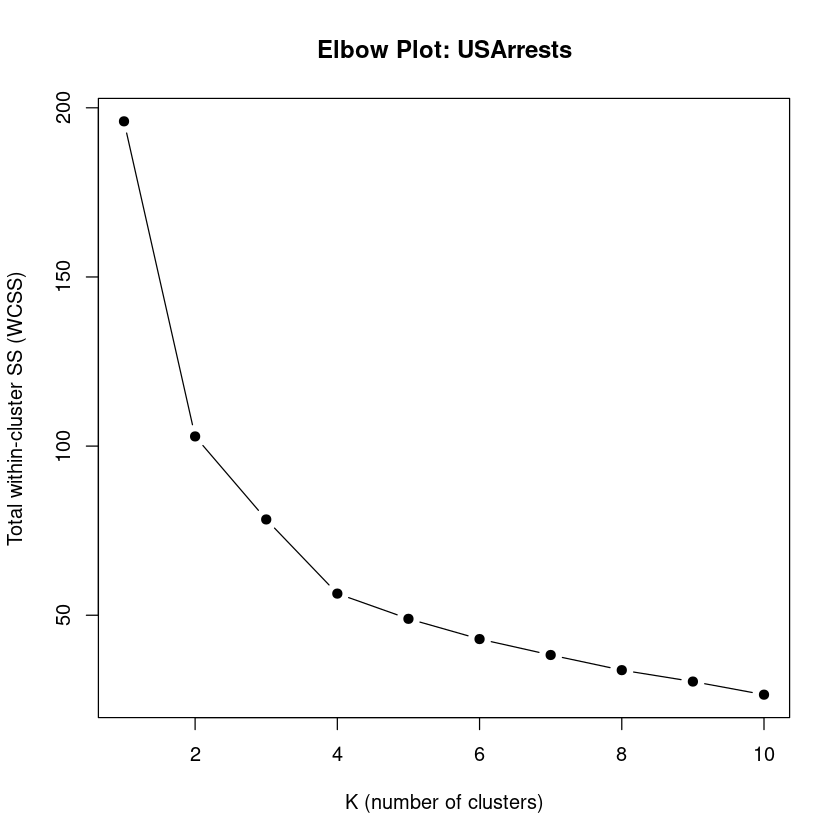

```r
#k-Means Clustering (K = 4)
set.seed(7271)
km = kmeans(X, centers = K, nstart = 50, iter.max = 200)

km$size                  # size of each cluster
km$tot.withinss          # total WCSS
kmeans_profile = aggregate(X, by = list(cluster = km$cluster), FUN = mean)
print(round(kmeans_profile, 2))

#Compare hierarchical vs k-means partitions
tab_compare = table(Hier = hc_cut, KMeans = km$cluster)
print(tab_compare)

#Elbow Plot (optional: explore K = 1..10 for k-means)
wcss = numeric(10)
set.seed(7271)
for (k in 1:10) {
  wcss[k] = kmeans(X, centers = k, nstart = 25)$tot.withinss
}
plot(1:10, wcss, type = "b", pch = 19,
     xlab = "K (number of clusters)", ylab = "Total within-cluster SS (WCSS)",
     main = "Elbow Plot: USArrests")

# Silhouette Analysis (optional)
# library(cluster)
  sil = silhouette(km$cluster, dist(X))
  plot(sil, main = "Silhouette Plot (k-means, K=4)")
  cat("Average silhouette width:", round(mean(sil[, 3]), 3), "\n")

# Name states by cluster (k-means)
split(states, km$cluster)
```